# Smoothing models

## Get data - smooth disturbed and control plots together - AGB growth

```r
library(mgcv); library(data.table); library(gratia); library(marginaleffects); library(ggplot2); library(dplyr); library(tidyr); library(zoo); library(slider); library(here)

#####test Paracou####

obs <- read.csv("G:/My Drive/cesab bioforest/Data/aggregated_data_v9.csv")

setDT(obs)

obs=obs[obs$Site=="Paracou"]


setnames(obs, "Plot", "subplot")

obs$plot=gsub("_.", "",obs$subplot )

obs <- obs[!Year%in%1984:1990]

obs <- dcast(
  obs,
  subplot + plot + Year ~ variable,
  value.var = "value"
)


##### upload data
load("../clim_by_site.rda")

clim_all=rbindlist(lapply(clim_by_site[["Paracou"]], function(x) x$climate[[1]]),
                   idcol = "plot")

#"Paracou", "Mbaiki", "Corinto", "SUAS", "Lesong", "Ulu Muda", "Sungai Lalang", "Tene", "Jari"

baseline <- clim_all[year >= 1981 & year <= 2010]


clim_stats <- baseline[, .(
  mean_tmax = mean(tmax),
  sd_tmax   = sd(tmax),
  mean_vpd   = mean(vpd),
  sd_vpd     = sd(vpd),
  mean_srad  = mean(srad),
  sd_srad    = sd(srad),
  mean_def  = mean(def),
  sd_def    = sd(def)
), by = month]

clim_all <- merge(clim_all, clim_stats, by = "month", all.x = TRUE)

clim_all[, `:=`(
  z_tmax = (tmax - mean_tmax) / sd_tmax,
  z_vpd  = (vpd  - mean_vpd)  / sd_vpd,
  z_srad = (srad - mean_srad) / sd_srad,
  z_def  = (def  - mean_def)  / sd_def
)]

#climate anomalies follow inventories. For Paracou, mean per year before 1996, two years after

clim_all[, year_bin :=
           ifelse(year <= 1995,
                  year,                     # keep original year
                  1997 + ((year - 1996) %/% 2) * 2   # 2-year bins
           )]


census_anom <- clim_all[,.(
  mean_z_tmax = mean(z_tmax, na.rm = TRUE),
  mean_z_vpd = mean(z_vpd, na.rm = TRUE),
  mean_z_srad = mean(z_srad, na.rm = TRUE),
  mean_z_def = mean(z_def, na.rm = TRUE)
),
by = .(plot, year_bin)]

#AGB values before 1991 are not consistent
census_anom=census_anom[year_bin>=1991]


merged <- merge(
  obs,
  census_anom,
  by.x = c("Year","plot"), by.y=c("year_bin","plot")
)


control=c(1,6,11,13,14,15)

merged$Treatment <- ifelse(merged$plot %in% control, "control", "disturbed")

merged$Treatment <- factor(merged$Treatment)
merged$plot <- factor(merged$plot)
merged$subplot <- factor(merged$subplot)
```

## GAM k=5 and k=8

**NAs for agb_growth - plots 13,14 and 15 miss data for 1991**

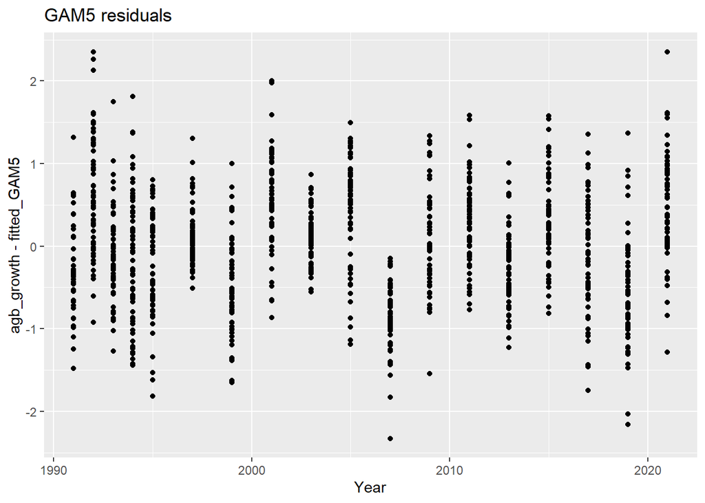

```r
merged <- merged %>%
  group_by(subplot) %>%
  mutate(
    fitted_GAM5 = predict(
      gam(agb_growth ~ s(Year, k = 5), data = cur_data()),
      newdata = cur_data()
    )
  ) %>%
  ungroup()

p1.1 <- ggplot(merged, aes(Year, agb_growth - fitted_GAM5)) +
  geom_point() +
  ggtitle("GAM5 residuals")

p1.1
```

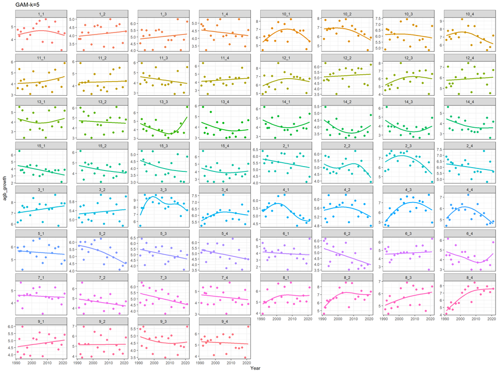

```r
ggplot(merged, aes(x = Year, y = fitted_GAM5, color = subplot)) +
  geom_line(size = 1) +  # predicted trajectory
  geom_point(data = merged,
             aes(x = Year, y = agb_growth, color = subplot),
             inherit.aes = FALSE, size = 2) +  # observed points
  facet_wrap(~ subplot, scales = "free_y")+
  theme_bw() +
  labs(x = "Year",
       y = "agb_growth", title="GAM-k=5") + theme(legend.position = "none")
```

**GAM at edges - higher standard error,** GAM uses many basis functions (Thin Plate Regression Splines (TPRS)) combined to estimate an unknown curve. Instead of minimizing just the residual error the model penalize large curvatures, which can be demonstrated with the standard errors. (for bs=fs, penalty is Shared among the subplots – it is supposed to control for overfitting) **

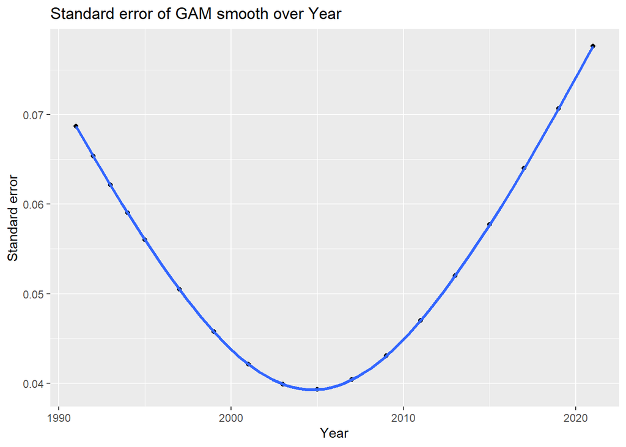

```r
#see SE at adges

m=gam(agb_growth ~ s(Year, k = 5), data = merged)
pred <- predict(m, newdata = merged, se.fit = TRUE)

setDT(merged)

merged[, se_GAM5 := pred$se.fit]


ggplot(merged, aes(Year, se_GAM5)) +
  geom_point(alpha = 0.3) +
  geom_smooth(se = FALSE, linewidth = 1.2) +
  labs(title = "Standard error of GAM smooth over Year",
       y = "Standard error")
```

**GAM k=8**

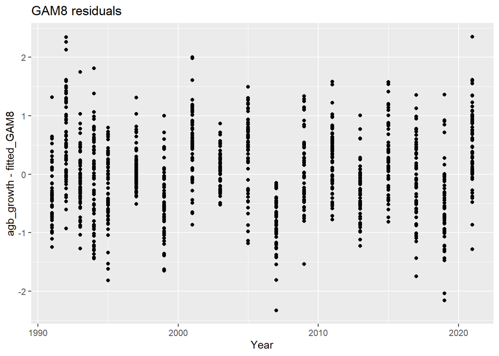

```r
merged <- merged %>%
  group_by(subplot) %>%
  mutate(
    fitted_GAM8 = predict(
      gam(agb_growth ~ s(Year, k = 8), data = cur_data()),
      newdata = cur_data()
    )
  )%>%
  ungroup()

p11.1 <- ggplot(merged, aes(Year, agb_growth - fitted_GAM8)) +
  geom_point() +
  ggtitle("GAM8 residuals")


p11.1
```

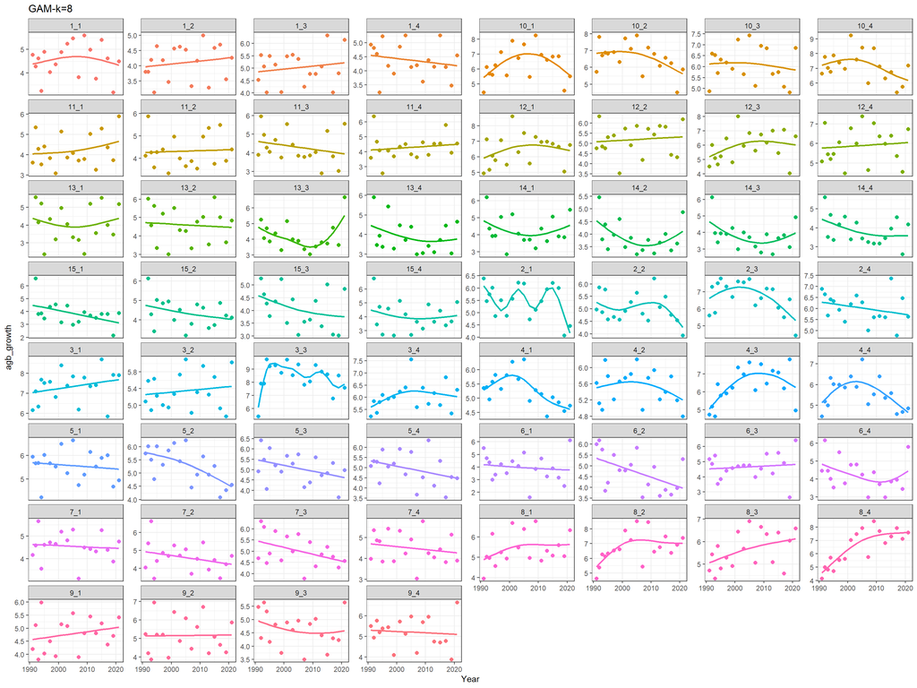

```r
p11=ggplot(merged, aes(x = Year, y = fitted_GAM8, color = subplot)) +
  geom_line(size = 1) +  # predicted trajectory
  geom_point(data = merged,
             aes(x = Year, y = agb_growth, color = subplot),
             inherit.aes = FALSE, size = 2) +  # observed points
  facet_wrap(~ subplot, scales = "free_y")+

  theme_bw() +
  labs(x = "Year",
       y = "agb_growth", title="GAM-k=8") + theme(legend.position = "none")

p11
```

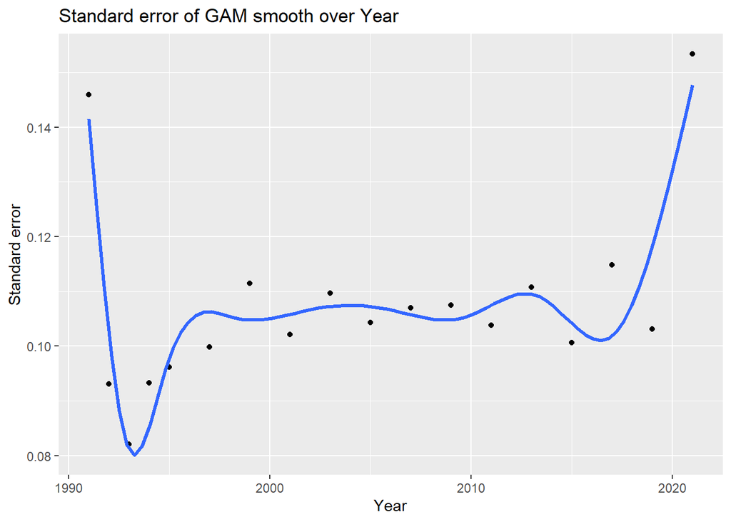

```r
m=gam(agb_growth ~ s(Year, k = 8), data = merged)
pred <- predict(m, newdata = merged, se.fit = TRUE)

setDT(merged)

merged[, se_GAM8 := pred$se.fit]


ggplot(merged, aes(Year, se_GAM8)) +
  geom_point(alpha = 0.3) +
  geom_smooth(se = FALSE, linewidth = 1.2) +
  labs(title = "Standard error of GAM smooth over Year",
       y = "Standard error")
```

## slider

**complete=TRUE (reject incomplete windows,** Per row: will keep 5 observations- in initial inventories = 5 years, after 1995 = 10 years..

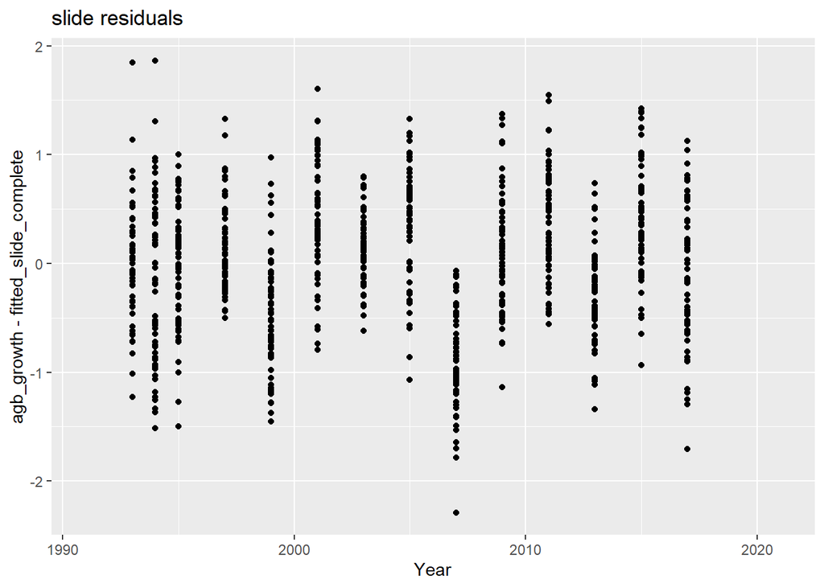

```r
merged <- merged %>%
  group_by(subplot) %>%
  arrange(Year) %>%
  mutate(fitted_slide_complete = slide_dbl(agb_growth, mean, .before = 2, .after = 2, .complete=TRUE))%>%
  ungroup()



p3.1 <- ggplot(merged, aes(Year, agb_growth - fitted_slide_complete)) +
  geom_point() +
  ggtitle("slide residuals")

p3.1
```

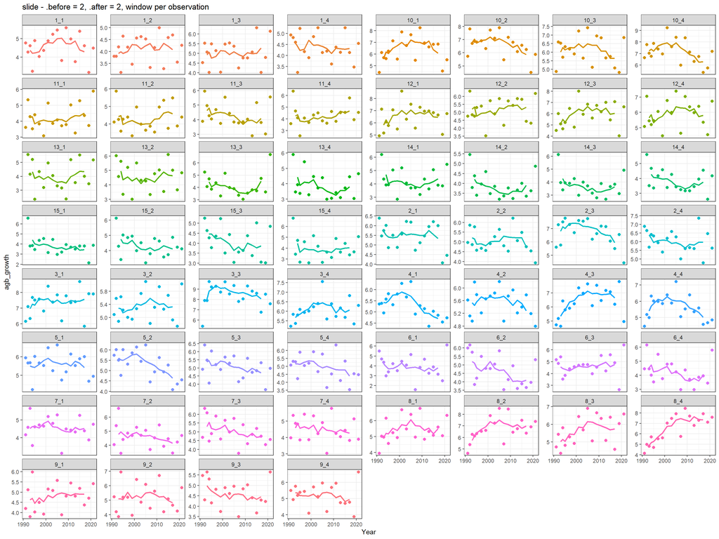

```r
p3=ggplot(merged, aes(x = Year, y = fitted_slide_complete, color = subplot)) +
  geom_line(size = 1) +  # predicted trajectory
  geom_point(data = merged,
             aes(x = Year, y = agb_growth, color = subplot),
             inherit.aes = FALSE, size = 2) +  # observed points
  facet_wrap(~subplot, scales = "free_y")+
  theme_bw() +
  labs(x = "Year",
       y = "agb_growth", title="slide - .before = 2, .after = 2, window per observation")+ theme(legend.position = "none")

p3
```

**Differences on window sizes among methods**

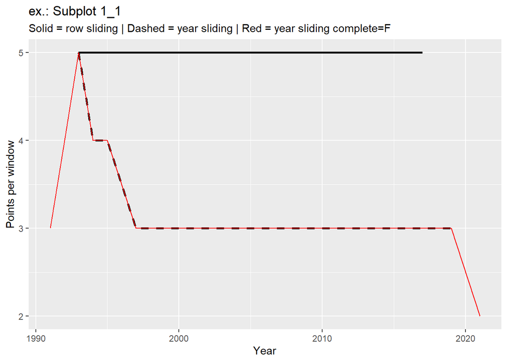

```r
merged <- merged %>% arrange(subplot, Year)


merged <- merged %>%
  group_by(subplot) %>%
  mutate(
    # ----------------------------
    # 1) Sliding by ROWS
    # ----------------------------
    slide_row = slide_dbl(
      agb_growth,
      mean,
      .before = 2,
      .after  = 2,
      .complete = TRUE
    ),

    n_row = slide_int(
      agb_growth,
      ~ length(.x),
      .before = 2,
      .after  = 2,
      .complete = TRUE
    ),

    # ----------------------------
    # 2) Sliding by YEARS
    # ----------------------------
    slide_year = slide_index_dbl(
      .x = agb_growth,
      .i = Year,
      .f = mean,
      .before = 2,
      .after  = 2,
      .complete = TRUE
    ),

    n_year = slide_index_int(
      .x = agb_growth,
      .i = Year,
      .f = ~ length(.x),
      .before = 2,
      .after  = 2,
      .complete = TRUE
    ),
        # ----------------------------
    # 2) Sliding by YEARS complete=F
    # ----------------------------
    slide_year_false = slide_index_dbl(
      .x = agb_growth,
      .i = Year,
      .f = mean,
      .before = 2,
      .after  = 2,
      .complete = FALSE
    ),

    n_year_false = slide_index_int(
      .x = agb_growth,
      .i = Year,
      .f = ~ length(.x),
      .before = 2,
      .after  = 2,
      .complete = FALSE
    )
  ) %>%
  ungroup()

ggplot(
  filter(merged, subplot == "1_1"),
  aes(x = Year)
) +
  geom_line(aes(y = n_row), linewidth = 1) +
  geom_line(aes(y = n_year), linetype = "dashed", linewidth = 1) +
    geom_line(aes(y = n_year_false), color = "red") +
  labs(
    y = "Points per window",
    title = "ex.: Subplot 1_1",
    subtitle = "Solid = row sliding | Dashed = year sliding | Red = year sliding complete=F"
  )
```

```r
#plot(merged$slide_year_false, merged$slide_year)
```

**complete=TRUE (reject incomplete windows** Per year: will keep 5 observations- in initial inventories = 5 years, after 1995 = 5 years (but with INCOMPLETE windows)..

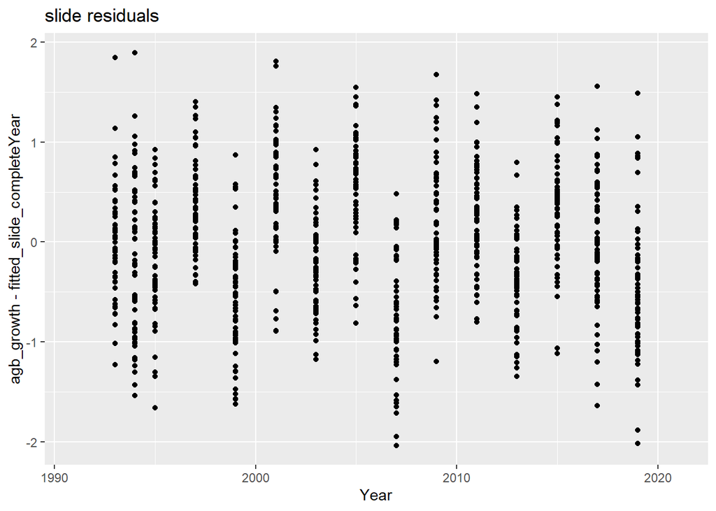

```r
merged <- merged %>%
  group_by(subplot) %>%
  arrange(Year) %>%
  mutate(fitted_slide_completeYear = slide_index_dbl(agb_growth, Year, mean, .before = 2, .after = 2, .complete=TRUE))%>%
  ungroup()

p33.1 <- ggplot(merged, aes(Year, agb_growth - fitted_slide_completeYear)) +
  geom_point() +
  ggtitle("slide residuals")

p33.1
```

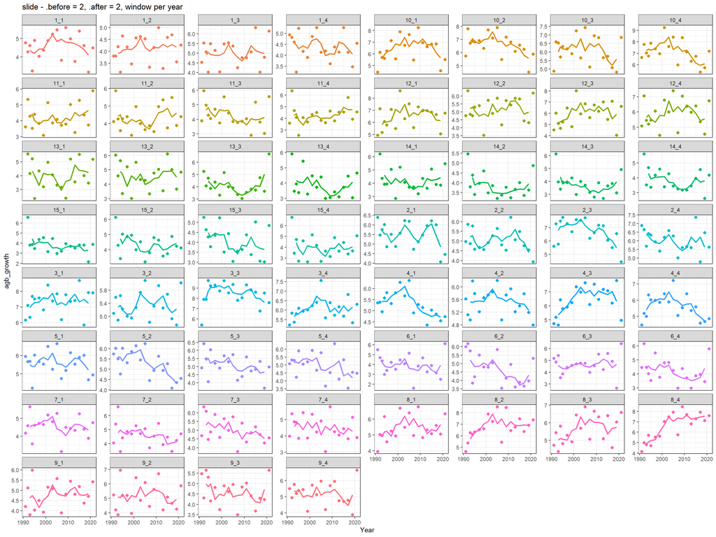

```r
p33=ggplot(merged, aes(x = Year, y = fitted_slide_completeYear, color = subplot)) +
  geom_line(size = 1) +  # predicted trajectory
  geom_point(data = merged,
             aes(x = Year, y = agb_growth, color = subplot),
             inherit.aes = FALSE, size = 2) +  # observed points
  facet_wrap(~subplot, scales= "free_y")+
  theme_bw() +
  labs(x = "Year",
       y = "agb_growth", title="slide - .before = 2, .after = 2, window per year")+ theme(legend.position = "none")

p33
```

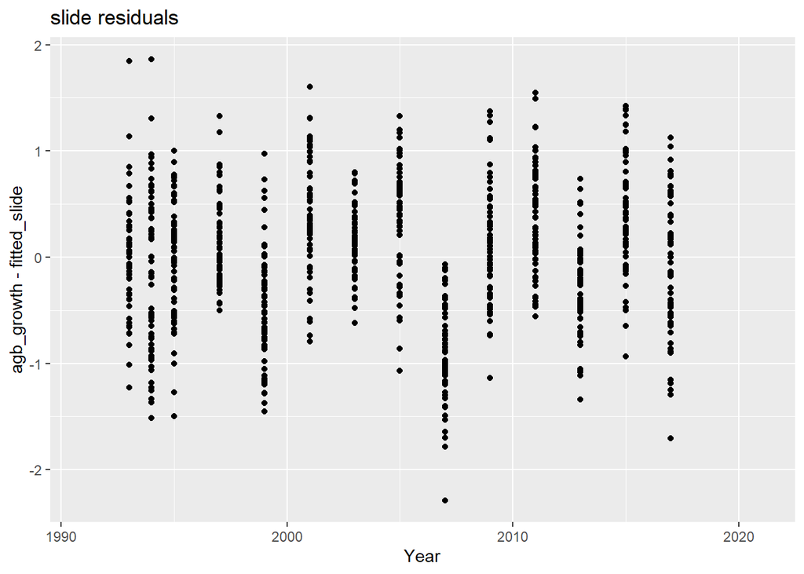

```r
merged <- merged %>%
  group_by(subplot) %>%
  arrange(Year) %>%
  mutate(fitted_slide = slide_dbl(agb_growth, mean, .before = 2, .after = 2, .complete=TRUE))%>%
  ungroup()

p333.1 <- ggplot(merged, aes(Year, agb_growth - fitted_slide)) +
  geom_point() +
  ggtitle("slide residuals")


p333.1
```